# Limpieza y analisis de datos

Monica Romero Ferron

28 de diciembre, 2020

# 1. Descripción del dataset. ¿Por qué es importante y qué pregunta/problema pretende responder?

1 - fixed acidity (acidez fija): la mayoria de los acidos relacionados con el vino son fijos o no volatiles.

2 - volatile acidity (acidez volatil): cantidad de ácido acético en el vino.

3 - citric acid (ácido cítrico): puede añadir “frescura” y sabor a los vinos.

4 - residual sugar (azucar residual): cantidad de azúcar que queda después de que se detiene la fermentación.

5 - chlorides (cloruros): cantidad de sal en el vino.

6 - free sulfur dioxide (dióxido de azufre libre)

7 - total sulfur dioxide (dióxido de azufre total)

8 - density (densidad): cercanía de la densidad a la del agua dependiendo del porcentaje de alcohol y contenido de azucar.

9 - pH: describe que tan ácido es un vino en una escala de 0 a 14.

10 - sulphates (solfitos): aditivo de vino que puede contribuir a los niveles de dióxido de azufre.

11 - alcohol: el porcentaje de alcohol en el vino.

12 - quality (score between 0 and 10)

# 2. Integración y selección de los datos de interés a analizar.

A continuacion vamos a estudiar el dataset con el que vamos a trabajar y visualizar las variables que vamos a usar a lo largo de la practica.

```r
# Exploring and understanding data
df <- read.csv("winequality-red.csv", header = TRUE,sep = ";")
head(df)
```

```
##   fixed.acidity volatile.acidity citric.acid residual.sugar chlorides
## 1           7.4             0.70        0.00            1.9     0.076
## 2           7.8             0.88        0.00            2.6     0.098
## 3           7.8             0.76        0.04            2.3     0.092
## 4          11.2             0.28        0.56            1.9     0.075
## 5           7.4             0.70        0.00            1.9     0.076
## 6           7.4             0.66        0.00            1.8     0.075
##   free.sulfur.dioxide total.sulfur.dioxide density   pH sulphates alcohol
## 1                  11                   34  0.9978 3.51      0.56     9.4
## 2                  25                   67  0.9968 3.20      0.68     9.8
## 3                  15                   54  0.9970 3.26      0.65     9.8
## 4                  17                   60  0.9980 3.16      0.58     9.8
## 5                  11                   34  0.9978 3.51      0.56     9.4
## 6                  13                   40  0.9978 3.51      0.56     9.4
##   quality
## 1       5
## 2       5
## 3       5
## 4       6
## 5       5
## 6       5
```

```r
dim(df)
```

```
## [1] 1599   12
```

```r
str(df)
```

```
## 'data.frame':    1599 obs. of  12 variables:
##  $ fixed.acidity       : num  7.4 7.8 7.8 11.2 7.4 7.4 7.9 7.3 7.8 7.5 ...
##  $ volatile.acidity    : num  0.7 0.88 0.76 0.28 0.7 0.66 0.6 0.65 0.58 0.5 ...
##  $ citric.acid         : num  0 0 0.04 0.56 0 0 0.06 0 0.02 0.36 ...
##  $ residual.sugar      : num  1.9 2.6 2.3 1.9 1.9 1.8 1.6 1.2 2 6.1 ...
##  $ chlorides           : num  0.076 0.098 0.092 0.075 0.076 0.075 0.069 0.065 0.073 0.071 ...
##  $ free.sulfur.dioxide : num  11 25 15 17 11 13 15 15 9 17 ...
##  $ total.sulfur.dioxide: num  34 67 54 60 34 40 59 21 18 102 ...
##  $ density             : num  0.998 0.997 0.997 0.998 0.998 ...
##  $ pH                  : num  3.51 3.2 3.26 3.16 3.51 3.51 3.3 3.39 3.36 3.35 ...
##  $ sulphates           : num  0.56 0.68 0.65 0.58 0.56 0.56 0.46 0.47 0.57 0.8 ...
##  $ alcohol             : num  9.4 9.8 9.8 9.8 9.4 9.4 9.4 10 9.5 10.5 ...
##  $ quality             : int  5 5 5 6 5 5 5 7 7 5 ...
```

```r
summary(df)
```

```
##  fixed.acidity   volatile.acidity  citric.acid    residual.sugar
##  Min.   : 4.60   Min.   :0.1200   Min.   :0.000   Min.   : 0.900
##  1st Qu.: 7.10   1st Qu.:0.3900   1st Qu.:0.090   1st Qu.: 1.900
##  Median : 7.90   Median :0.5200   Median :0.260   Median : 2.200
##  Mean   : 8.32   Mean   :0.5278   Mean   :0.271   Mean   : 2.539
##  3rd Qu.: 9.20   3rd Qu.:0.6400   3rd Qu.:0.420   3rd Qu.: 2.600
##  Max.   :15.90   Max.   :1.5800   Max.   :1.000   Max.   :15.500
##    chlorides       free.sulfur.dioxide total.sulfur.dioxide    density
##  Min.   :0.01200   Min.   : 1.00       Min.   :  6.00       Min.   :0.9901
##  1st Qu.:0.07000   1st Qu.: 7.00       1st Qu.: 22.00       1st Qu.:0.9956
##  Median :0.07900   Median :14.00       Median : 38.00       Median :0.9968
##  Mean   :0.08747   Mean   :15.87       Mean   : 46.47       Mean   :0.9967
##  3rd Qu.:0.09000   3rd Qu.:21.00       3rd Qu.: 62.00       3rd Qu.:0.9978
##  Max.   :0.61100   Max.   :72.00       Max.   :289.00       Max.   :1.0037
##        pH          sulphates         alcohol         quality
##  Min.   :2.740   Min.   :0.3300   Min.   : 8.40   Min.   :3.000
##  1st Qu.:3.210   1st Qu.:0.5500   1st Qu.: 9.50   1st Qu.:5.000
##  Median :3.310   Median :0.6200   Median :10.20   Median :6.000
##  Mean   :3.311   Mean   :0.6581   Mean   :10.42   Mean   :5.636
##  3rd Qu.:3.400   3rd Qu.:0.7300   3rd Qu.:11.10   3rd Qu.:6.000
##  Max.   :4.010   Max.   :2.0000   Max.   :14.90   Max.   :8.000
```

# 3. Limpieza de los datos.

## 3.1. ¿Los datos contienen ceros o elementos vacíos? ¿Cómo gestionarías cada uno de estos casos?

```r
# Números de valores desconocidos por campo
sapply(df, function(x) sum(is.na(x)))
```

```
##        fixed.acidity     volatile.acidity          citric.acid
##                    0                    0                    0
##       residual.sugar            chlorides  free.sulfur.dioxide
##                    0                    0                    0
## total.sulfur.dioxide              density                   pH
##                    0                    0                    0
##            sulphates              alcohol              quality
##                    0                    0                    0
```

## 3.2. Identificación y tratamiento de valores extremos.

Utilizaremos la funcion boxplots.stats en R. Asi nos mostrara todos los puntos atipicos:

```r
boxplot.stats(df$fixed.acidity)$out
```

```
##  [1] 12.8 12.8 15.0 15.0 12.5 13.3 13.4 12.4 12.5 13.8 13.5 12.6 12.5 12.8 12.8
## [16] 14.0 13.7 13.7 12.7 12.5 12.8 12.6 15.6 12.5 13.0 12.5 13.3 12.4 12.5 12.9
## [31] 14.3 12.4 15.5 15.5 15.6 13.0 12.7 13.0 12.7 12.4 12.7 13.2 13.2 13.2 15.9
## [46] 13.3 12.9 12.6 12.6
```

```r
boxplot.stats(df$volatile.acidity)$out
```

```
##  [1] 1.130 1.020 1.070 1.330 1.330 1.040 1.090 1.040 1.240 1.185 1.020 1.035
## [13] 1.025 1.115 1.020 1.020 1.580 1.180 1.040
```

```r
boxplot.stats(df$citric.acid)$out
```

```
## [1] 1
```

```r
boxplot.stats(df$chlorides)$out
```

```
##   [1] 0.176 0.170 0.368 0.341 0.172 0.332 0.464 0.401 0.467 0.122 0.178 0.146
##  [13] 0.236 0.610 0.360 0.270 0.039 0.337 0.263 0.611 0.358 0.343 0.186 0.213
##  [25] 0.214 0.121 0.122 0.122 0.128 0.120 0.159 0.124 0.122 0.122 0.174 0.121
##  [37] 0.127 0.413 0.152 0.152 0.125 0.122 0.200 0.171 0.226 0.226 0.250 0.148
##  [49] 0.122 0.124 0.124 0.143 0.222 0.039 0.157 0.422 0.034 0.387 0.415 0.157
##  [61] 0.157 0.243 0.241 0.190 0.132 0.126 0.038 0.165 0.145 0.147 0.012 0.012
##  [73] 0.039 0.194 0.132 0.161 0.120 0.120 0.123 0.123 0.414 0.216 0.171 0.178
##  [85] 0.369 0.166 0.166 0.136 0.132 0.132 0.123 0.123 0.123 0.403 0.137 0.414
##  [97] 0.166 0.168 0.415 0.153 0.415 0.267 0.123 0.214 0.214 0.169 0.205 0.205
## [109] 0.039 0.235 0.230 0.038
```

```r
boxplot.stats(df$free.sulfur.dioxide)$out
```

```
##  [1] 52 51 50 68 68 43 47 54 46 45 53 52 51 45 57 50 45 48 43 48 72 43 51 51 52
## [26] 55 55 48 48 66
```

```r
boxplot.stats(df$total.sulfur.dioxide)$out
```

```
##  [1] 145 148 136 125 140 136 133 153 134 141 129 128 129 128 143 144 127 126 145
## [20] 144 135 165 124 124 134 124 129 151 133 142 149 147 145 148 155 151 152 125
## [39] 127 139 143 144 130 278 289 135 160 141 141 133 147 147 131 131 131
```

```r
boxplot.stats(df$density)$out
```

```
##  [1] 0.99160 0.99160 1.00140 1.00150 1.00150 1.00180 0.99120 1.00220 1.00220
## [10] 1.00140 1.00140 1.00140 1.00140 1.00320 1.00260 1.00140 1.00315 1.00315
## [19] 1.00315 1.00210 1.00210 0.99170 0.99220 1.00260 0.99210 0.99154 0.99064
## [28] 0.99064 1.00289 0.99162 0.99007 0.99007 0.99020 0.99220 0.99150 0.99157
## [37] 0.99080 0.99084 0.99191 1.00369 1.00369 1.00242 0.99182 1.00242 0.99182
```

```r
boxplot.stats(df$pH)$out
```

```
##  [1] 3.90 3.75 3.85 2.74 3.69 3.69 2.88 2.86 3.74 2.92 2.92 2.92 3.72 2.87 2.89
## [16] 2.89 2.92 3.90 3.71 3.69 3.69 3.71 3.71 2.89 2.89 3.78 3.70 3.78 4.01 2.90
## [31] 4.01 3.71 2.88 3.72 3.72
```

```r
boxplot.stats(df$sulphates)$out
```

```
##  [1] 1.56 1.28 1.08 1.20 1.12 1.28 1.14 1.95 1.22 1.95 1.98 1.31 2.00 1.08 1.59
## [16] 1.02 1.03 1.61 1.09 1.26 1.08 1.00 1.36 1.18 1.13 1.04 1.11 1.13 1.07 1.06
## [31] 1.06 1.05 1.06 1.04 1.05 1.02 1.14 1.02 1.36 1.36 1.05 1.17 1.62 1.06 1.18
## [46] 1.07 1.34 1.16 1.10 1.15 1.17 1.17 1.33 1.18 1.17 1.03 1.17 1.10 1.01
```

```r
boxplot.stats(df$alcohol)$out
```

```
##  [1] 14.00000 14.00000 14.00000 14.00000 14.90000 14.00000 13.60000 13.60000
##  [9] 13.60000 14.00000 14.00000 13.56667 13.60000
```

```r
boxplot.stats(df$quality)$out
```

```
##  [1] 8 8 8 8 8 3 8 8 8 3 8 3 8 3 3 8 8 8 8 8 3 3 8 8 3 3 3 8
```

En el caso de los outliers si suponemos que los datos son recogidos de forma correcta y son datos reales se incluyen en el estudio pero si consideramos que los datos se estan recogiendo de forma incorrecta los deberemos eliminar del dataset.

En este dataset en concreto vemos que los datos son correctos y se analizaran conjuntamente con el resto de datos.

# 4. Análisis de los datos.

## 4.1. Selección de los grupos de datos que se quieren analizar/comparar (planificación de los análisis a aplicar).

```r
library(MASS)
```

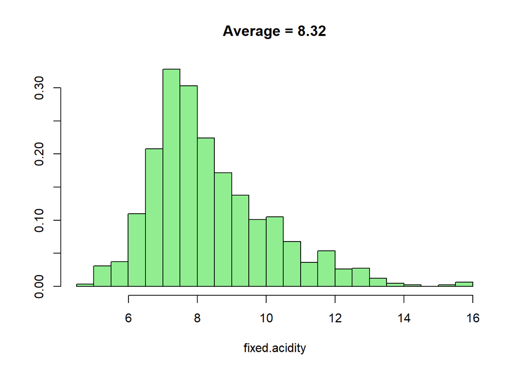

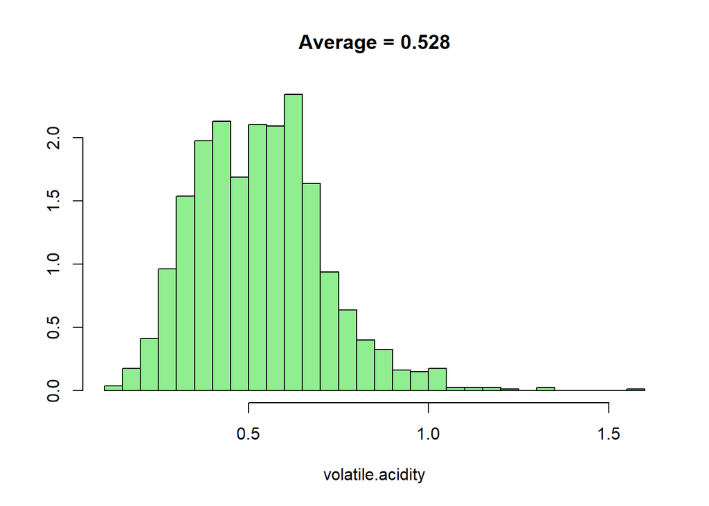

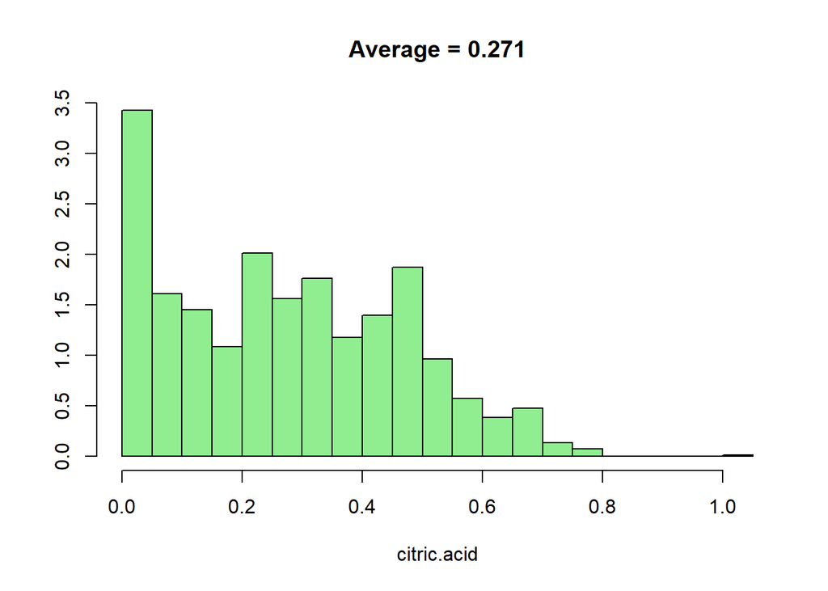

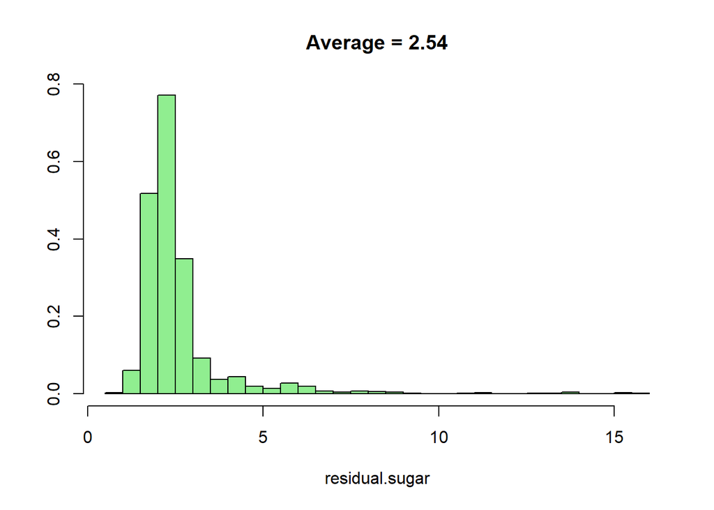

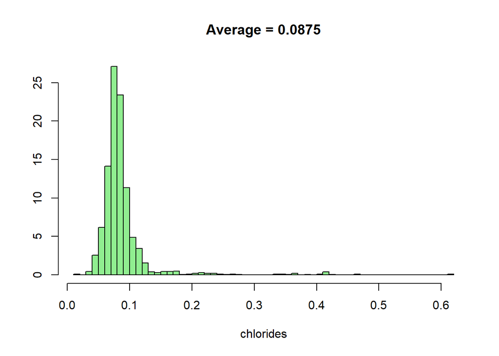

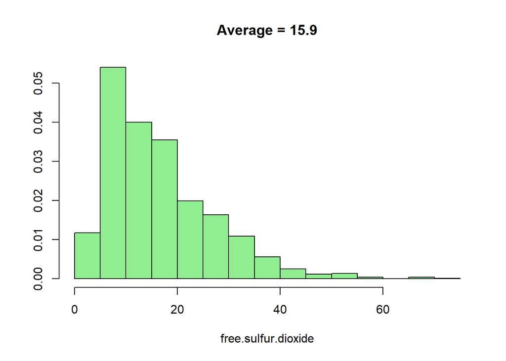

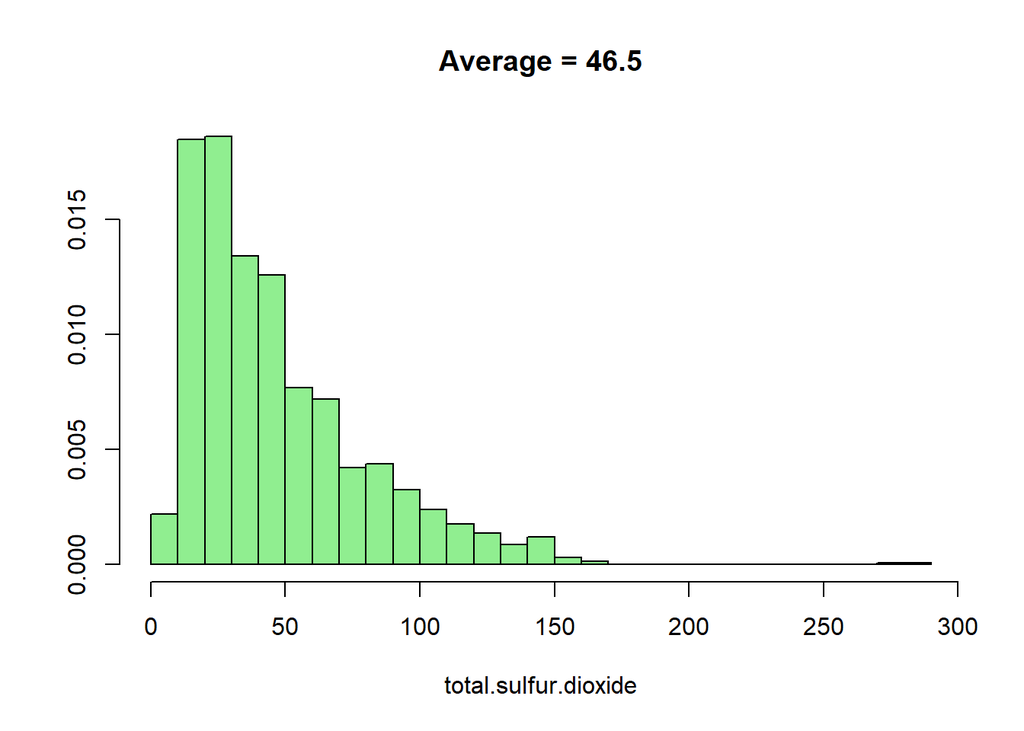

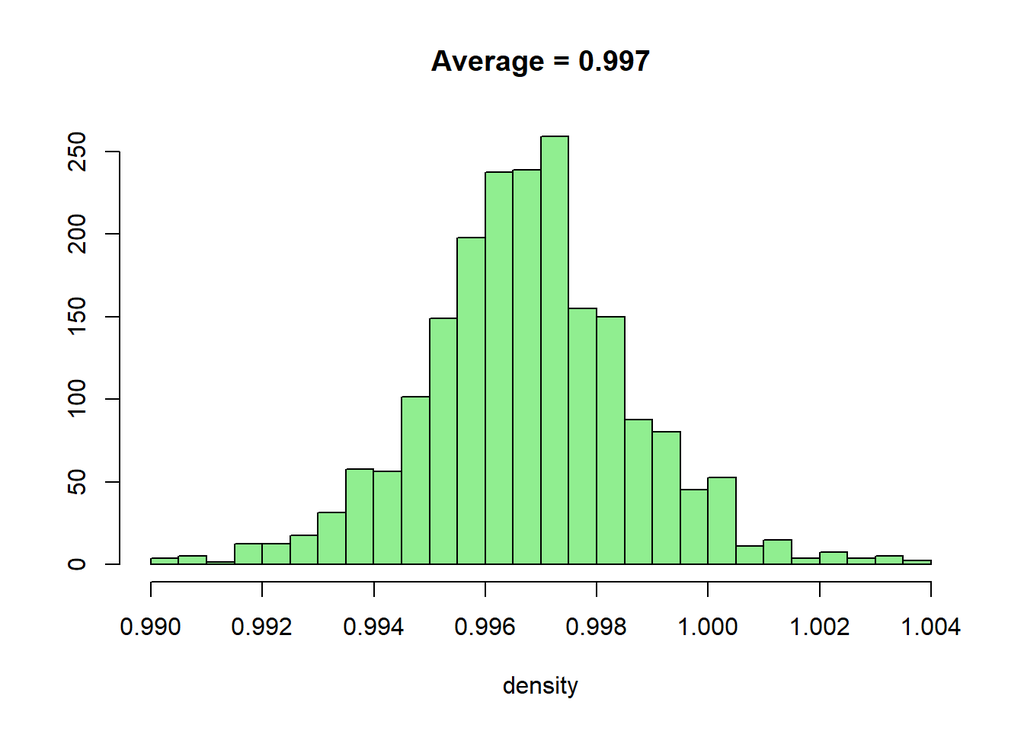

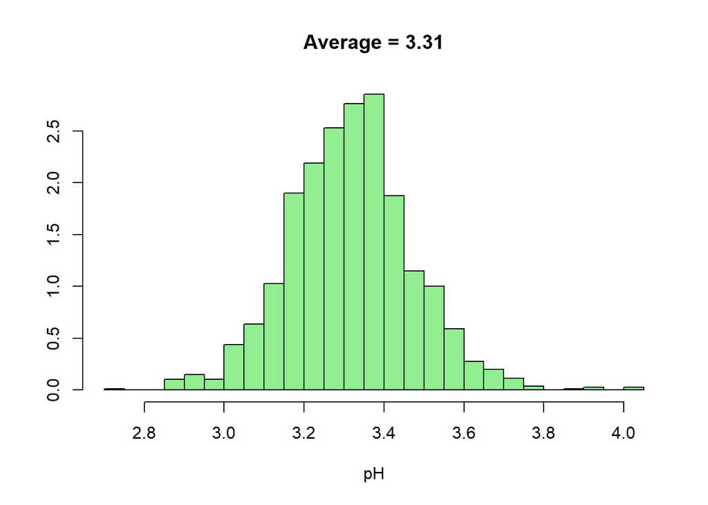

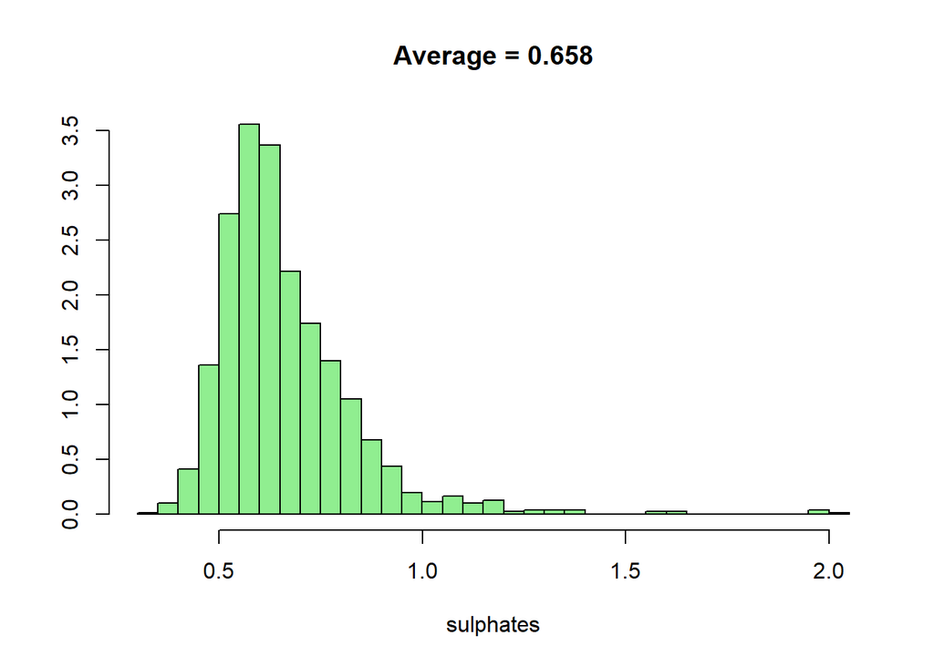

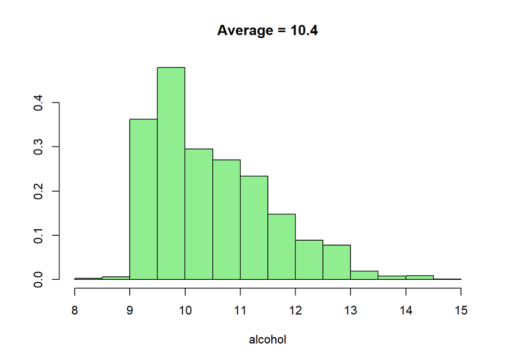

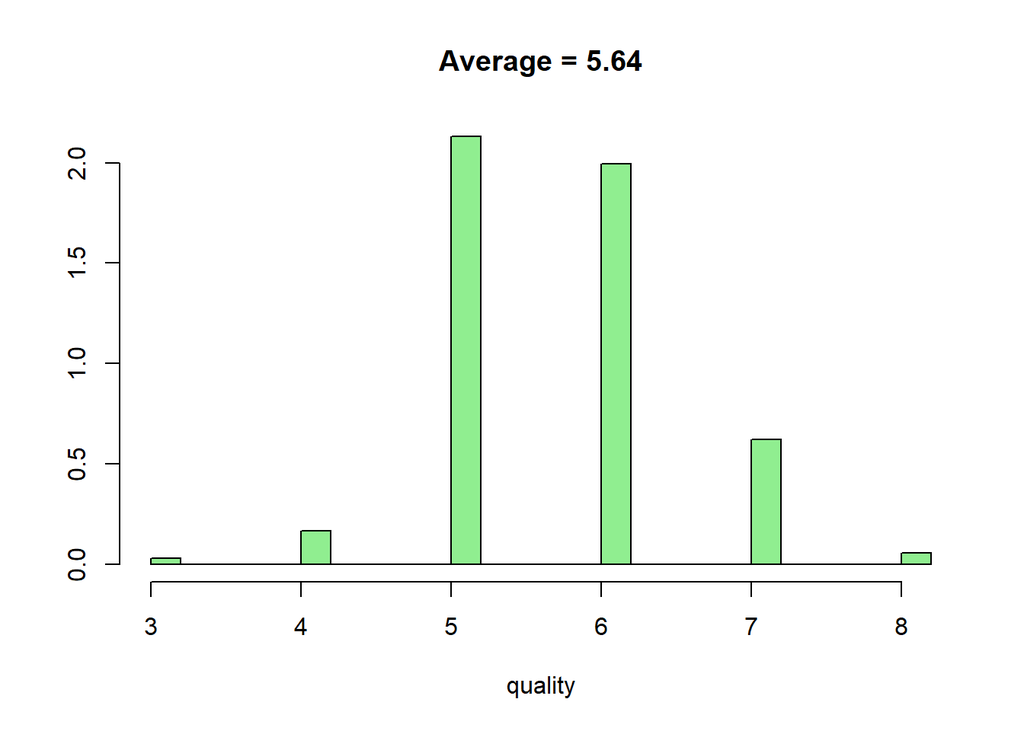

```r
library(dplyr)
for ( i in 1:12 ) {
  truehist(df[[i]], xlab = names(df)[i], col = 'lightgreen', main = paste("Average =",signif(mean(df[[i]]),3)))
}
```

Para la metrica queality vamos a realizar una agrupacion por vino de calidad superior o inferior. Calidad superior seran los vinos con la metrica quality >= 6 y los de calidad infreior quality <=5.

```r
df$quality_2<-ifelse(df$quality>=6,1,0)
with(df,table(df$quality_2))
```

```
##
##   0   1
## 744 855
```

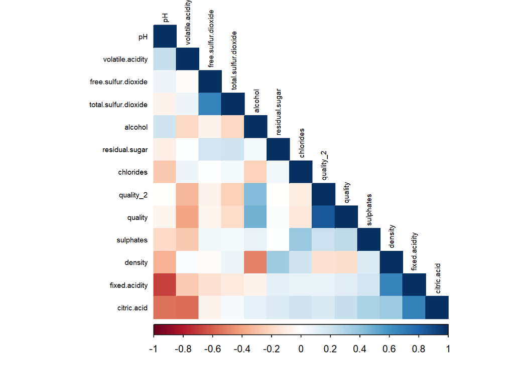

```r
library(corrplot)
corMatrix <- cor(df)
corrplot(corMatrix, order = "FPC", method = "color", type = "lower", tl.cex = 0.6, tl.col = 'black')
```

Estos serian datos de interes a analizar entre ellos para ver cuanta relacion tiene con la calidad del vino.

En nuestro caso unas metricas interesantes a realizar el estudio seria con las relacionadas con quality, por ejemplo, la metrica alcochol que son las que tienen una relacion mas directa entre ellos:

*Alcohol y Quality*

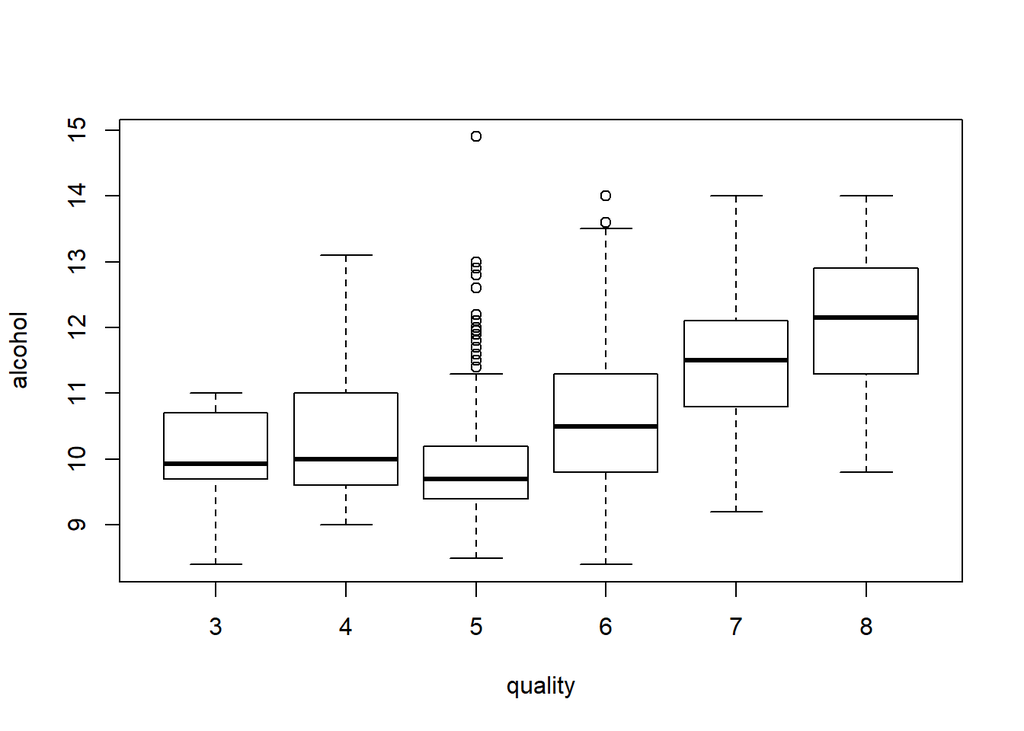

```r
boxplot(alcohol~quality, data = df)
```

*Volatile Acidity y Quality*

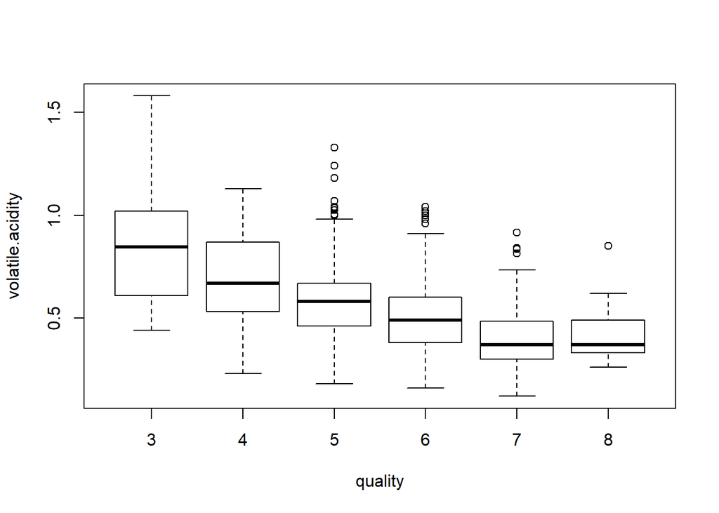

```r
boxplot(volatile.acidity~quality, data = df)
```

## 4.2. Comprobación de la normalidad y homogeneidad de la varianza.

Para la comprobacion de la normalidad vamos a usar la prueba de normalidad de Anderson-Darling

```r
library(nortest)
alpha = 0.05
col.names = colnames(df)
for (i in 1:ncol(df)) {
if (i == 1) cat("Variables que no siguen una distribución normal:\n")
if (is.integer(df[,i]) | is.numeric(df[,i])) {
p_val = ad.test(df[,i])$p.value
if (p_val < alpha) {
cat(col.names[i])
# Format output
if (i < ncol(df) - 1) cat(", ")
if (i %% 3 == 0) cat("\n")
}
}
}
```

```
## Variables que no siguen una distribución normal:
## fixed.acidity, volatile.acidity, citric.acid,
## residual.sugar, chlorides, free.sulfur.dioxide,
## total.sulfur.dioxide, density, pH,
## sulphates, alcohol, quality
## quality_2
```

Podemos ademas observarlo mediante las funciones QQplots de R.

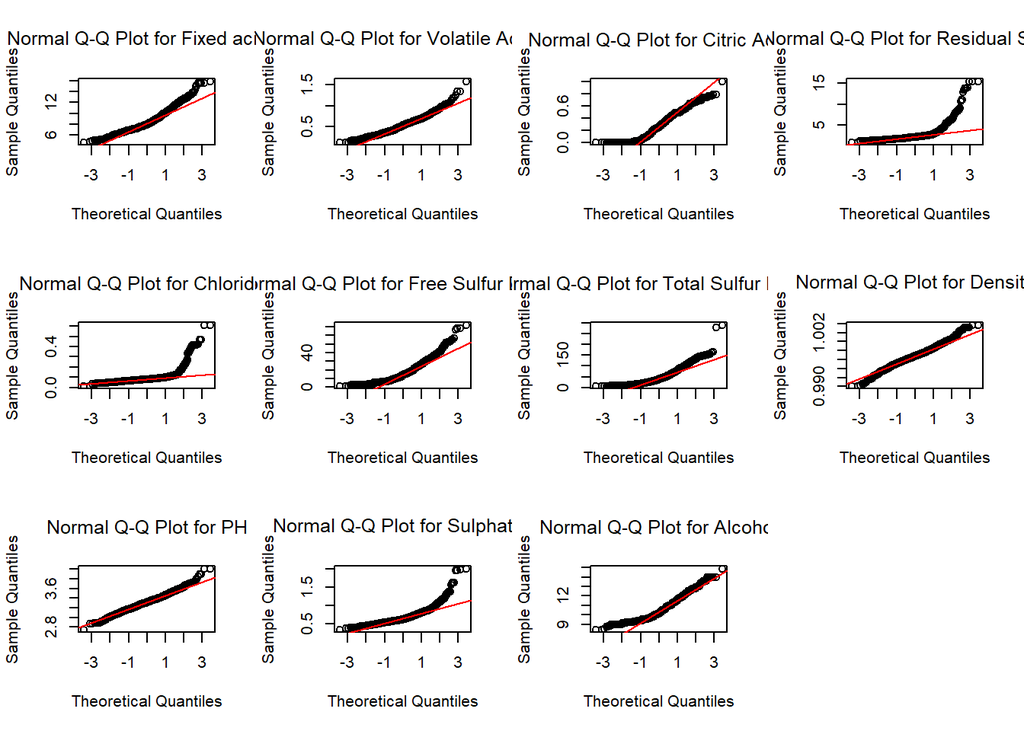

```r
par(mfrow=c(3,4))
qqnorm(df$fixed.acidity, main = expression('Normal Q-Q Plot for Fixed acidity'))
qqline(df$fixed.acidity,col=2)
qqnorm(df$volatile.acidity, main = expression('Normal Q-Q Plot for Volatile Acidity'))
qqline(df$volatile.acidity,col=2)
qqnorm(df$citric.acid, main = expression('Normal Q-Q Plot for Citric Acid'))
qqline(df$citric.acid,col=2)
qqnorm(df$residual.sugar, main = expression('Normal Q-Q Plot for Residual Sugar'))
qqline(df$residual.sugar,col=2)
qqnorm(df$chlorides, main = expression('Normal Q-Q Plot for Chlorides'))
qqline(df$chlorides,col=2)
qqnorm(df$free.sulfur.dioxide, main = expression('Normal Q-Q Plot for Free Sulfur Dioxide'))
qqline(df$free.sulfur.dioxide,col=2)
qqnorm(df$total.sulfur.dioxide, main = expression('Normal Q-Q Plot for Total Sulfur Dioxide'))
qqline(df$total.sulfur.dioxide,col=2)
qqnorm(df$density, main = expression('Normal Q-Q Plot for Density'))
qqline(df$density,col=2)
qqnorm(df$pH, main = expression('Normal Q-Q Plot for PH'))
qqline(df$pH,col=2)
qqnorm(df$sulphates, main = expression('Normal Q-Q Plot for Sulphates'))
qqline(df$sulphates,col=2)
qqnorm(df$alcohol, main = expression('Normal Q-Q Plot for Alcohol'))
qqline(df$alcohol,col=2)
```

Se puede ver como realmente ninguna metrica se distribuye como una normal gracias al test de QQplot.

Para el estudio de la homogeneidad de varianzas vamos a usar el test de Fligner-Killen:

```r
fligner.test(quality ~ alcohol, data = df)
```

```
##
##  Fligner-Killeen test of homogeneity of variances
##
## data:  quality by alcohol
## Fligner-Killeen:med chi-squared = 135.98, df = 64, p-value = 4.157e-07
```

```r
fligner.test(quality ~ volatile.acidity, data = df)
```

```
##
##  Fligner-Killeen test of homogeneity of variances
##
## data:  quality by volatile.acidity
## Fligner-Killeen:med chi-squared = 147.35, df = 142, p-value = 0.3621
```

## 4.3. Aplicación de pruebas estadísticas para comparar los grupos de datos. En función de los datos y el objetivo del estudio, aplicar pruebas de contraste de hipótesis, correlaciones, regresiones, etc. Aplicar al menos tres métodos de análisis diferentes.

En este apartado podriamos añadir el estudio de correlaciones usado anteriormente para ver la relacion entre las metricas. Ademas de observar la correlacion mediante la matriz anterior vamos a realizar test de correlaciones entre las variables de interes:

```r
cor.test(df$alcohol,df$quality)
```

```
##
##  Pearson's product-moment correlation
##
## data:  df$alcohol and df$quality
## t = 21.639, df = 1597, p-value < 2.2e-16
## alternative hypothesis: true correlation is not equal to 0
## 95 percent confidence interval:
##  0.4373540 0.5132081
## sample estimates:
##       cor
## 0.4761663
```

```r
cor.test(df$pH,df$quality)
```

```
##
##  Pearson's product-moment correlation
##
## data:  df$pH and df$quality
## t = -2.3109, df = 1597, p-value = 0.02096
## alternative hypothesis: true correlation is not equal to 0
## 95 percent confidence interval:
##  -0.106451268 -0.008734972
## sample estimates:
##         cor
## -0.05773139
```

```r
cor.test(df$volatile.acidity,df$quality)
```

```
##
##  Pearson's product-moment correlation
##
## data:  df$volatile.acidity and df$quality
## t = -16.954, df = 1597, p-value < 2.2e-16
## alternative hypothesis: true correlation is not equal to 0
## 95 percent confidence interval:
##  -0.4313210 -0.3482032
## sample estimates:
##        cor
## -0.3905578
```

```r
cor.test(df$citric.acid,df$quality)
```

```
##
##  Pearson's product-moment correlation
##
## data:  df$citric.acid and df$quality
## t = 9.2875, df = 1597, p-value < 2.2e-16
## alternative hypothesis: true correlation is not equal to 0
## 95 percent confidence interval:
##  0.1793415 0.2723711
## sample estimates:
##       cor
## 0.2263725
```

```r
cor.test(df$sulphates,df$quality)
```

```
##
##  Pearson's product-moment correlation
##
## data:  df$sulphates and df$quality
## t = 10.38, df = 1597, p-value < 2.2e-16
## alternative hypothesis: true correlation is not equal to 0
## 95 percent confidence interval:
##  0.2049011 0.2967610
## sample estimates:
##       cor
## 0.2513971
```

Observamos que las metricas sulphates, citric, volatile acidity, ph y alcohol su p-valor es menor que 0.05, es decir, estas metricas estan relcionadas con la calidad del vino y son muy utiles para realizar el posterior estudio.

### 4.3.1 Hipotesis nula

Realicemos un test de *hipotesis nula con la metrica alcohol y quality. Vamos estudiar si no hay diferencia significativa en la concentracion de alcohol de un vino de calidad superior y uno de calidad inferior, es decir, la cantidad de alcohol es independiente en la calidad del vino.

```r
t.test(df$alcohol~df$quality_2)
```

```
##
##  Welch Two Sample t-test
##
## data:  df$alcohol by df$quality_2
## t = -19.782, df = 1516.8, p-value < 2.2e-16
## alternative hypothesis: true difference in means is not equal to 0
## 95 percent confidence interval:
##  -1.020622 -0.836479
## sample estimates:
## mean in group 0 mean in group 1
##        9.926478       10.855029
```

Observamos como el p-valor es menor que 0.05 con lo cual se rechaza la hipotesis nula. Eso quiere decir que si que hay relacion entre la concentracion de alcohol y la calidad de los vinos.

*Hipotesis nula volatile acidity:* no hay diferencia singificativa en la metrica volatile acidity entre un vino con calidad superior o inferior.

```r
t.test(df$volatile.acidity~df$quality_2)
```

```
##
##  Welch Two Sample t-test
##
## data:  df$volatile.acidity by df$quality_2
## t = 13.478, df = 1515.4, p-value < 2.2e-16
## alternative hypothesis: true difference in means is not equal to 0
## 95 percent confidence interval:
##  0.0985674 0.1321456
## sample estimates:
## mean in group 0 mean in group 1
##       0.5895027       0.4741462
```

En este caso el p-valor es inferior a 0.05 con lo cual se rechaza la hipotesis nula. Hay relacion entre la metrica volatile acidity y la calidad del vino.

*Hipotesis nula citric.acid:* no hay diferencia singificativa en la metrica citric acid entre un vino con calidad superior o inferior.

```r
t.test(df$citric.acid~df$quality_2)
```

```
##
##  Welch Two Sample t-test
##
## data:  df$citric.acid by df$quality_2
## t = -6.4799, df = 1592.5, p-value = 1.22e-10
## alternative hypothesis: true difference in means is not equal to 0
## 95 percent confidence interval:
##  -0.08093360 -0.04332173
## sample estimates:
## mean in group 0 mean in group 1
##       0.2377554       0.2998830
```

En este caso el p-valor es inferior a 0.05 con lo cual se rechaza la hipotesis nula. Hay relacion entre la metrica citric y la calidad del vino.

*Hipotesis nula sulphates:* no hay diferencia singificativa en la metrica sulphates entre un vino con calidad superior o inferior.

```r
t.test(df$sulphates~df$quality_2)
```

```
##
##  Welch Two Sample t-test
##
## data:  df$sulphates by df$quality_2
## t = -8.8531, df = 1494.5, p-value < 2.2e-16
## alternative hypothesis: true difference in means is not equal to 0
## 95 percent confidence interval:
##  -0.09049978 -0.05767010
## sample estimates:
## mean in group 0 mean in group 1
##       0.6185349       0.6926199
```

En este caso el p-valor es inferior a 0.05 con lo cual se rechaza la hipotesis nula. Hay relacion entre la metrica sulphates y la calidad del vino.

###4.3.2 Regresion lineal

A continuacion realizamos un modelo de regresion lineal con las variables:

```r
modelo1 <- lm(quality~volatile.acidity + chlorides + free.sulfur.dioxide + total.sulfur.dioxide + pH + sulphates + alcohol, data=df)
summary(modelo1)
```

```
##
## Call:
## lm(formula = quality ~ volatile.acidity + chlorides + free.sulfur.dioxide +
##     total.sulfur.dioxide + pH + sulphates + alcohol, data = df)
##
## Residuals:
##      Min       1Q   Median       3Q      Max
## -2.68918 -0.36757 -0.04653  0.46081  2.02954
##
## Coefficients:
##                        Estimate Std. Error t value Pr(>|t|)
## (Intercept)           4.4300987  0.4029168  10.995  < 2e-16 ***
## volatile.acidity     -1.0127527  0.1008429 -10.043  < 2e-16 ***
## chlorides            -2.0178138  0.3975417  -5.076 4.31e-07 ***
## free.sulfur.dioxide   0.0050774  0.0021255   2.389    0.017 *
## total.sulfur.dioxide -0.0034822  0.0006868  -5.070 4.43e-07 ***
## pH                   -0.4826614  0.1175581  -4.106 4.23e-05 ***
## sulphates             0.8826651  0.1099084   8.031 1.86e-15 ***
## alcohol               0.2893028  0.0167958  17.225  < 2e-16 ***
## ---
## Signif. codes:  0 '***' 0.001 '**' 0.01 '*' 0.05 '.' 0.1 ' ' 1
##
## Residual standard error: 0.6477 on 1591 degrees of freedom
## Multiple R-squared:  0.3595, Adjusted R-squared:  0.3567
## F-statistic: 127.6 on 7 and 1591 DF,  p-value: < 2.2e-16
```

Tenemos un coeficiente de determinacion del 35%. A continuacion podriamos hacer predicciones con este modelo:

```r
data<-data.frame(volatile.acidity=0.57,chlorides=0.2,free.sulfur.dioxide =25, total.sulfur.dioxide=100, pH =3,65, sulphates =0.78, alcohol=10)
predict(modelo1,data)
```

```
##        1
## 5.361499
```

# 5. Representación de los resultados a partir de tablas y gráficas.

A lo largo de todo el proyecto se han realizado tablas y graficas donde podemos obtener las diversas conclusiones.

# 6. Resolución del problema. A partir de los resultados obtenidos, ¿cuáles son las conclusiones? ¿Los resultados permiten responder al problema?

El siguiente paso a realizar fue hacer un estudio de correlacion de las variables para saber cuales estan mas realacionadas con la calidad del vino tanto de forma negativa como positiva la correlacion. Cuando hemos obtenido las metricas mas interesantes y que mas relacion tienen con la calidad de los vinos se ha hecho un estudio de su normalidad y homocedasticidad. Por ultimo se realizar una regresion lineal con las metricas mas interesante para poder hacer una prediccion de la calidad del vino.

# 7. Código.